# Winter1 冬第1周上机内容

ChenXG 陈栩淦 3160104014

12/17/2018

```r
Sys.setlocale("LC_ALL", locale = "en_US.UTF-8")
```

```
## [1] "en_US.UTF-8/en_US.UTF-8/en_US.UTF-8/C/en_US.UTF-8/en_US.UTF-8"
```

```r
setwd("~/Project/RegressionAnalysis")
```

```r
library(PerformanceAnalytics)  # for kurtosis and skewneww
library(DAAG)  # for vif, eigen and kappa
library(MASS)  # for lm.ridge
# get descriptive statistics
decribeStats <- function(x){
  name <- c("mean", "Std", "Kurtosis", "Skewness", "Max", "Min", "Median")
  data_decribe <- c(mean(x), sd(x), kurtosis(x), skewness(x),
                    max(x), min(x), median(x))
  names(data_decribe) <- name

  return (data_decribe)
}
```

## 题1

10次试验得观测数据如下。 若以$x_1, x_2$为回归自变量，问它们之间是否存在多重共线性关系？

```r
# loading data
y <- c(16.3, 16.8, 19.2, 18.0, 19.5,
         20.9, 21.1, 20.9, 20.3, 22.0)
x1 <- c(1.1, 1.4, 1.7, 1.7, 1.8,
          1.8, 1.9, 2.0, 2.3, 2.4)
x2 <- c(1.1, 1.5, 1.8, 1.7, 1.9,
          1.8, 1.8, 2.1, 2.4, 2.5)

data <- data.frame(y, x1, x2)
```

```r
dS_x1 <- decribeStats(x1)
dS_x2 <- decribeStats(x2)
dS <- data.frame(dS_x1, dS_x2)
dS
```

```
##               dS_x1       dS_x2
## mean      1.8100000  1.86000000
## Std       0.3842742  0.40879226
## Kurtosis -0.3794193 -0.31551324
## Skewness -0.2040897 -0.09751868
## Max       2.4000000  2.50000000
## Min       1.1000000  1.10000000
## Median    1.8000000  1.80000000
```

```r
lm.sol <- lm(y~., data = data)
summary(lm.sol)
```

```
##
## Call:
## lm(formula = y ~ ., data = data)
##
## Residuals:
##     Min      1Q  Median      3Q     Max
## -1.3107 -0.3727  0.1168  0.5054  1.1176
##
## Coefficients:
##             Estimate Std. Error t value Pr(>|t|)
## (Intercept)   11.292      1.463   7.719 0.000114 ***
## x1            11.307      4.719   2.396 0.047740 *
## x2            -6.591      4.436  -1.486 0.180941
## ---
## Signif. codes:  0 '***' 0.001 '**' 0.01 '*' 0.05 '.' 0.1 ' ' 1
##
## Residual standard error: 0.9072 on 7 degrees of freedom
## Multiple R-squared:  0.8267, Adjusted R-squared:  0.7772
## F-statistic:  16.7 on 2 and 7 DF,  p-value: 0.002167
```

```r
lm.sol$coefficients
```

```
## (Intercept)          x1          x2
##    11.29244    11.30730    -6.59068
```

我们可以得到回归方程：
$$\begin{equation}
y = 11.30730\times x_1 -6.59068 \times x_2 + 11.29244.
\end{equation}$$

```r
X <- cbind(x1, x2)
rho <- cor(X)
rho
```

```
##           x1        x2
## x1 1.0000000 0.9859988
## x2 0.9859988 1.0000000
```

简单地，通过$x_1$和$x_2$的样本相关系数矩阵可以看出，它们之间存在高度的相关性。

### 多重共线性诊断

下面我们做多重共线性诊断。

```r
# VIF
vif(lm.sol)
```

```
##     x1     x2
## 35.963 35.963
```

可以看到两个自变量的VIF值都大于10，因此存在着严重的多重共线性。

```r
# 特征根诊断法
eigen(rho)
```

```
## eigen() decomposition
## $values
## [1] 1.98599875 0.01400125
##
## $vectors
##           [,1]       [,2]
## [1,] 0.7071068 -0.7071068
## [2,] 0.7071068  0.7071068
```

再看特征根诊断法，其中有1个特征根近似为零，则有1个多重共线性关系。

```r
# 条件数诊断法
kappa(rho, exact = TRUE)
```

```
## [1] 141.8444
```

最后看条件数诊断法，CI在100～1000之间，则可以认为有着较强的多重共线性。

- 结论：$x_1$和$x_2$存在着较强的多重共线性。

## 题2

10次试验得观测数据如下。 试用岭迹法求$y$关于$x_1, x_2$得岭回归方程，并画出岭迹图。

### 岭估计方法

基于**题1**的结果，我们可以知道，$x_1$和$x_2$存在着较强的多重共线性。 下面我们用岭估计的方法寻找岭回归方程。

```r
datascale <- scale(data)
datascale
```

```
##                y          x1          x2
##  [1,] -1.6651016 -1.84763897 -1.85913501
##  [2,] -1.4049294 -1.06694645 -0.88064290
##  [3,] -0.1561033 -0.28625392 -0.14677382
##  [4,] -0.7805164 -0.28625392 -0.39139684
##  [5,]  0.0000000 -0.02602308  0.09784921
##  [6,]  0.7284819 -0.02602308 -0.14677382
##  [7,]  0.8325508  0.23420776 -0.14677382
##  [8,]  0.7284819  0.49443860  0.58709527
##  [9,]  0.4162754  1.27513112  1.32096435
## [10,]  1.3008606  1.53536196  1.56558738
## attr(,"scaled:center")
##     y    x1    x2
## 19.50  1.81  1.86
## attr(,"scaled:scale")
##         y        x1        x2
## 1.9218047 0.3842742 0.4087923
```

```r
data2 <- data.frame(datascale)
data2
```

```
##             y          x1          x2
## 1  -1.6651016 -1.84763897 -1.85913501
## 2  -1.4049294 -1.06694645 -0.88064290
## 3  -0.1561033 -0.28625392 -0.14677382
## 4  -0.7805164 -0.28625392 -0.39139684
## 5   0.0000000 -0.02602308  0.09784921
## 6   0.7284819 -0.02602308 -0.14677382
## 7   0.8325508  0.23420776 -0.14677382
## 8   0.7284819  0.49443860  0.58709527
## 9   0.4162754  1.27513112  1.32096435
## 10  1.3008606  1.53536196  1.56558738
```

```r
rr.sol <- lm.ridge(y~0+x1+x2, data = data2,
                   lambda = c(seq(0, 0.01, by = 0.0001),
                              seq(0.02, 0.1, by = 0.01),
                              seq(0.2, 1, by = 0.1)))
rr.sol
```

```
##               x1          x2
## 0.0000 2.2609506 -1.40192133
## 0.0001 2.2596414 -1.40061637
## 0.0002 2.2583339 -1.39931328
## 0.0003 2.2570284 -1.39801205
## 0.0004 2.2557247 -1.39671268
## 0.0005 2.2544228 -1.39541515
## 0.0006 2.2531228 -1.39411948
## 0.0007 2.2518247 -1.39282565
## 0.0008 2.2505284 -1.39153367
## 0.0009 2.2492339 -1.39024351
## 0.0010 2.2479413 -1.38895520
## 0.0011 2.2466504 -1.38766871
## 0.0012 2.2453615 -1.38638404
## 0.0013 2.2440743 -1.38510120
## 0.0014 2.2427889 -1.38382017
## 0.0015 2.2415054 -1.38254096
## 0.0016 2.2402237 -1.38126356
## 0.0017 2.2389438 -1.37998796
## 0.0018 2.2376656 -1.37871417
## 0.0019 2.2363893 -1.37744217
## 0.0020 2.2351148 -1.37617197
## 0.0021 2.2338421 -1.37490356
## 0.0022 2.2325711 -1.37363694
## 0.0023 2.2313019 -1.37237210
## 0.0024 2.2300346 -1.37110903
## 0.0025 2.2287689 -1.36984775
## 0.0026 2.2275051 -1.36858823
## 0.0027 2.2262430 -1.36733049
## 0.0028 2.2249827 -1.36607450
## 0.0029 2.2237242 -1.36482028
## 0.0030 2.2224674 -1.36356782
## 0.0031 2.2212124 -1.36231711
## 0.0032 2.2199591 -1.36106815
## 0.0033 2.2187075 -1.35982093
## 0.0034 2.2174577 -1.35857546
## 0.0035 2.2162097 -1.35733172
## 0.0036 2.2149634 -1.35608973
## 0.0037 2.2137188 -1.35484946
## 0.0038 2.2124759 -1.35361092
```

[output cut: 65 more lines]

```
## 0.0500 1.7779468 -0.92107479
## 0.0600 1.7102604 -0.85381854
## 0.0700 1.6489997 -0.79298753
## 0.0800 1.5932885 -0.73770562
## 0.0900 1.5424030 -0.68724902
## 0.1000 1.4957401 -0.64101456
## 0.2000 1.1793926 -0.32892789
## 0.3000 1.0058881 -0.15964199
## 0.4000 0.8958827 -0.05381349
## 0.5000 0.8196212  0.01831212
## 0.6000 0.7634318  0.07040598
## 0.7000 0.7201531  0.10962909
## 0.8000 0.6856707  0.14009515
## 0.9000 0.6574525  0.16433559
## 1.0000 0.6338551  0.18399352
```

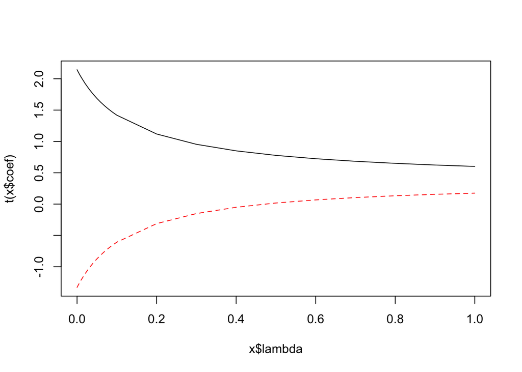

```r
plot(rr.sol)
```

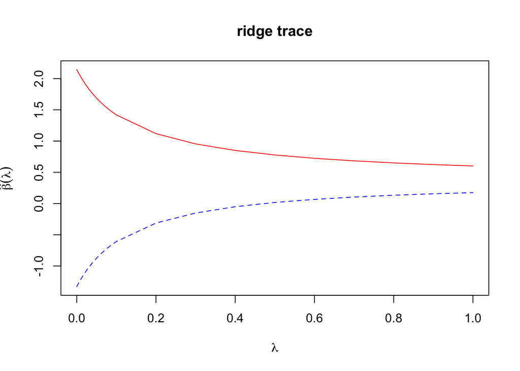

```r
matplot(rr.sol$lambda, t(rr.sol$coef), type = "l", col = c("red", "blue", "black"),
        main = "ridge trace", xlab = expression(lambda), ylab = expression(hat(beta)(lambda)))
```

根据岭迹图选择岭参数**k = 0.6**，则标准化变量的岭回归方程为
$$\hat{v} = 0.7634318 \times x_1 + 0.07040598 \times x_2.$$

```r
attr(datascale,"scaled:center")
```

```
##     y    x1    x2
## 19.50  1.81  1.86
```

```r
attr(datascale, "scaled:scale")
```

```
##         y        x1        x2
## 1.9218047 0.3842742 0.4087923
```

转化成原始变量的岭回归方程：
$$\frac{\hat{y} - 19.50}{1.9218047} = 0.7634318 \times \frac{x_1 - 1.81}{0.3842742} + 0.07040598 \times \frac{x_2 - 1.86}{0.4087923},$$

即：
$$\hat{y} = 3.818021 \times x_1 + 0.3309909 \times x_2 + 11.97395.$$

## 题3

对某种商品的销量$y$进行调查，并考虑有关的四个因素：$x_1$表示居民可支配收入，$x_2$表示该商品的平均价格指数，$x_3$表示该商品的社会保有量，$x_4$表示其他消费品平均价格指数。下面是调查数据。利用主成分方法建立$y$与$x_1, x_2, x_3, x_4$的回归方程。

```r
y <- c(8.4, 9.6, 10.4, 10.4, 12.2, 14.2, 15.8, 17.9, 19.6, 20.8)
x1 <- c(82.9, 88.0, 99.9, 105.3, 117.7, 131.0, 148.2, 161.8, 174.2, 184.7)
x2 <- c(92.0, 93.0, 96.0, 94.0, 100.0, 101.0, 105.0, 112.0, 112.0, 112.0)
x3 <- c(17.1, 21.3, 25.1, 29.0, 34.0, 40.0, 44.0, 49.0, 51.0, 53.0)
x4 <- c(94.0, 96.0, 97.0, 97.0, 100.0, 101.0, 104.0, 109.0, 111.0, 111.0)

data <- data.frame(y, x1, x2, x3, x4)
```

```r
lm.sol <- lm(y~., data = data)
summary(lm.sol)
```

```
##
## Call:
## lm(formula = y ~ ., data = data)
##
## Residuals:
##         1         2         3         4         5         6         7
## -0.041204  0.378874 -0.007332 -0.462807 -0.215669  0.478954 -0.086734
##         8         9        10
## -0.105363 -0.072881  0.134162
##
## Coefficients:
##              Estimate Std. Error t value Pr(>|t|)
## (Intercept) -18.46821   10.73845  -1.720   0.1461
## x1            0.10309    0.03786   2.723   0.0416 *
## x2           -0.03663    0.12886  -0.284   0.7876
## x3           -0.04474    0.07060  -0.634   0.5541
## x4            0.23935    0.21403   1.118   0.3143
## ---
## Signif. codes:  0 '***' 0.001 '**' 0.01 '*' 0.05 '.' 0.1 ' ' 1
##
## Residual standard error: 0.3681 on 5 degrees of freedom
## Multiple R-squared:  0.9961, Adjusted R-squared:  0.9931
## F-statistic: 323.4 on 4 and 5 DF,  p-value: 3.211e-06
```

```r
lm.sol$coefficients
```

```
##  (Intercept)           x1           x2           x3           x4
## -18.46821156   0.10308836  -0.03663266  -0.04473532   0.23934648
```

### 多重共线性诊断

```r
X <- cbind(x1, x2, x3, x4)
rho <- cor(X)
rho
```

```
##           x1        x2        x3        x4
## x1 1.0000000 0.9803556 0.9883145 0.9876656
## x2 0.9803556 1.0000000 0.9699616 0.9917959
## x3 0.9883145 0.9699616 1.0000000 0.9694773
## x4 0.9876656 0.9917959 0.9694773 1.0000000
```

通过样本相关系数矩阵可以直观看出，它们之间存在高度的相关性。

```r
# VIF
vif(lm.sol)
```

```
##      x1      x2      x3      x4
## 126.280  72.827  55.440 125.120
```

可以看到四个自变量的VIF值都大于10，因此存在着严重的多重共线性。

```r
# 特征根诊断法
eigen(rho)
```

```
## eigen() decomposition
## $values
## [1] 3.943813553 0.039962805 0.012586520 0.003637121
##
## $vectors
##            [,1]       [,2]       [,3]       [,4]
## [1,] -0.5015908 -0.2371037  0.5788473  0.5975988
## [2,] -0.4997889  0.4926217 -0.6104554  0.3672588
## [3,] -0.4979539 -0.7068667 -0.3682957 -0.3416720
## [4,] -0.5006593  0.4488265  0.3957754 -0.6255053
```

根据特征根诊断法，其中有3个特征根近似为零，则有3个多重共线性关系。

```r
# 条件数诊断法
kappa(rho, exact = TRUE)
```

```
## [1] 1084.323
```

通过条件数诊断法，CI大于1000，则可以认为有着严重的多重共线性。

### 主成分方法

为了消除多重共线性的影响，做主成分回归：

```r
datascale <- scale(data)
datascale
```

```
##                 y         x1          x2         x3         x4
##  [1,] -1.25079905 -1.2760920 -1.19388697 -1.4876883 -1.2477006
##  [2,] -0.97937792 -1.1360431 -1.07080584 -1.1631017 -0.9357754
##  [3,] -0.79843050 -0.8092625 -0.70156245 -0.8694282 -0.7798129
##  [4,] -0.79843050 -0.6609755 -0.94772471 -0.5680264 -0.7798129
##  [5,] -0.39129880 -0.3204647 -0.20923792 -0.1816139 -0.3119251
##  [6,]  0.06106975  0.0447607 -0.08615679  0.2820811 -0.1559626
##  [7,]  0.42296460  0.5170822  0.40616773  0.5912112  0.3119251
##  [8,]  0.89795158  0.8905458  1.26773565  0.9776237  1.0917380
##  [9,]  1.28246485  1.2310566  1.26773565  1.1321887  1.4036632
## [10,]  1.55388598  1.5193925  1.26773565  1.2867537  1.4036632
## attr(,"scaled:center")
##      y     x1     x2     x3     x4
##  13.93 129.37 101.70  36.35 102.00
## attr(,"scaled:scale")
##         y        x1        x2        x3        x4
##  4.421174 36.415871  8.124722 12.939539  6.411795
```

```r
data2 <- data.frame(datascale)
data2
```

```
##              y         x1          x2         x3         x4
## 1  -1.25079905 -1.2760920 -1.19388697 -1.4876883 -1.2477006
## 2  -0.97937792 -1.1360431 -1.07080584 -1.1631017 -0.9357754
## 3  -0.79843050 -0.8092625 -0.70156245 -0.8694282 -0.7798129
## 4  -0.79843050 -0.6609755 -0.94772471 -0.5680264 -0.7798129
## 5  -0.39129880 -0.3204647 -0.20923792 -0.1816139 -0.3119251
## 6   0.06106975  0.0447607 -0.08615679  0.2820811 -0.1559626
## 7   0.42296460  0.5170822  0.40616773  0.5912112  0.3119251
## 8   0.89795158  0.8905458  1.26773565  0.9776237  1.0917380
## 9   1.28246485  1.2310566  1.26773565  1.1321887  1.4036632
## 10  1.55388598  1.5193925  1.26773565  1.2867537  1.4036632
```

```r
y.pr <- princomp(~x1+x2+x3+x4, data = data2, cor = TRUE)
summary(y.pr, loadings = TRUE)
```

```
## Importance of components:
##                           Comp.1      Comp.2     Comp.3       Comp.4
## Standard deviation     1.9859037 0.199906992 0.11218966 0.0603085506
## Proportion of Variance 0.9859534 0.009990701 0.00314663 0.0009092803
## Cumulative Proportion  0.9859534 0.995944090 0.99909072 1.0000000000
##
## Loadings:
##    Comp.1 Comp.2 Comp.3 Comp.4
## x1  0.502  0.237  0.579  0.598
## x2  0.500 -0.493 -0.610  0.367
## x3  0.498  0.707 -0.368 -0.342
## x4  0.501 -0.449  0.396 -0.626
```

容易看到，后三个特征根分别为
$$\lambda_2 = 0.199906992^2 = 0.03996281 \approx 0, \\
\lambda_3 = 0.11218966^2 = 0.01258652 \approx 0, \\
\lambda_4 = 0.0603085506^2 = 0.003637121 \approx 0.$$

并且第一个特征根的累计贡献率为$0.9859534 > 0.85$，所以我们只保留第一个主成分，删去后三个主成分。

第一个主成分对应的标准正交化特征向量为
$$\phi_1 = (0.502, 0.500, 0.498, 0.501)^{'},$$
对应的主成分为
$$z_1 = 0.502 \times x^*_1 + 0.500\times x^*_2 + 0.498 \times x^*_3 + 0.501 \times x ^*_4 .$$

计算主成分得分：

```r
pre = predict(y.pr)
pre
```

```
##         Comp.1      Comp.2      Comp.3       Comp.4
## 1  -2.74300221 -0.21717213  0.04664610  0.092431543
## 2  -2.26912529 -0.15180493  0.05701818 -0.094266513
## 3  -1.66536864 -0.11683915 -0.03013748  0.045923725
## 4  -1.55844739  0.27262184  0.10173123 -0.064513216
## 5  -0.53961155  0.04080947 -0.12051901 -0.011795871
## 6   0.04403012  0.33989164 -0.09182299 -0.003917754
## 7   0.96230840  0.21126360 -0.04524573  0.064368428
## 8   2.22802489 -0.22379838 -0.19645929 -0.020173666
## 9   2.65380615 -0.17110117  0.08143164 -0.067009629
## 10  2.88738552  0.01612921  0.19735735  0.058952953
```

进行主成分估计：

```r
z1 = pre[,1]
ys <- data2$y
data3 <- data.frame(ys, z1)

pc.sol <- lm(ys~0+z1, data = data3)
summary(pc.sol)
```

```
##
## Call:
## lm(formula = ys ~ 0 + z1, data = data3)
##
## Residuals:
##       Min        1Q    Median        3Q       Max
## -0.160685 -0.052024  0.007191  0.049433  0.181957
##
## Coefficients:
##    Estimate Std. Error t value Pr(>|t|)
## z1  0.47515    0.01647   28.85 3.52e-10 ***
## ---
## Signif. codes:  0 '***' 0.001 '**' 0.01 '*' 0.05 '.' 0.1 ' ' 1
##
## Residual standard error: 0.1034 on 9 degrees of freedom
## Multiple R-squared:  0.9893, Adjusted R-squared:  0.9881
## F-statistic: 832.1 on 1 and 9 DF,  p-value: 3.524e-10
```

可以得到主成分回归方程：
$$\begin{align}
\hat{u} & = 0.47515 \times z_1 \\
& = 0.47515 \times (0.502 \times x^*_1 + 0.500\times x^*_2 + 0.498 \times x^*_3 + 0.501 \times x ^*_4) \\
& = 0.2385253 \times x^*_1 + 0.237575 \times x^*_2 + 0.2366247 \times x^*_3 + 0.2380502 \times x^*_4.
\end{align}$$

```r
attr(datascale,"scaled:center")
```

```
##      y     x1     x2     x3     x4
##  13.93 129.37 101.70  36.35 102.00
```

```r
attr(datascale, "scaled:scale")
```

```
##         y        x1        x2        x3        x4
##  4.421174 36.415871  8.124722 12.939539  6.411795
```

转化成原始变量的回归方程，得到：

$$\begin{align}
\frac{\hat{y} - 13.93} {4.421174} & = 0.2385253 \times \frac{x_1 - 129.37}{36.415871} + 0.237575 \times \frac{x_2 - 101.70}{8.124722} \\
& + 0.2366247 \times \frac{x_3 - 36.35}{12.939539} + 0.2380502 \times \frac{x_4 - 102.00}{6.411795},
\end{align}$$

即
$$\hat{y} = 0.02895885 \times x_1 + 0.1292796 \times x_2 + 0.08084979\times x_3 + 0.1641446 \times x_4 -22.64578.$$